# Fashion Retail Capstone — Classification, Clustering & NLP on Customer Reviews

**Dataset:** Women's E-Commerce Clothing Reviews (23,486 reviews, 10 feature columns).

**Business framing.** An online fashion retailer has thousands of free-text customer reviews that nobody on the merchandising team has time to read. Leadership wants three connected deliverables:

1. **Early-warning classification** — flag reviews that indicate *"would not recommend"*.
2. **Product/segment clustering** — group product classes into merchandising tiers.
3. **Theme extraction** — a plain-English summary of what unhappy customers actually say.

**Notebook map**

| Section | Task |
| --- | --- |
| Task 0 | Setup, reproducibility, data load |
| Task 1 | Exploratory Data Analysis |
| Task 2 | NLP feature engineering |
| Task 3 | Model-ready dataset (split, encode, scale) |
| Task 4 | Classification on imbalanced data |
| Task 5 | Evaluation & threshold selection |
| Task 6 | Model explainability |
| Task 7 | Unsupervised clustering of product classes |
| Task 8 | Theme extraction from negative feedback |
| Task 9 | Executive synthesis |

**Reproducibility.** `random_state=42` is passed to every function that accepts one (`train_test_split`, `LogisticRegression`, `RandomForestClassifier`, `KMeans`). Re-running this notebook top-to-bottom reproduces every number in the written summary.

## Task 0 — Setup, reproducibility and data load

```python
# --- Standard library -------------------------------------------------------
import json
import re
import string
import warnings
from pathlib import Path

# --- Third party ------------------------------------------------------------
import numpy as np
import pandas as pd
import matplotlib as mpl
import matplotlib.pyplot as plt
from scipy import sparse
from textblob import TextBlob

from sklearn.dummy import DummyClassifier
from sklearn.feature_extraction.text import TfidfVectorizer
from sklearn.linear_model import LogisticRegression
from sklearn.ensemble import RandomForestClassifier
from sklearn.cluster import KMeans
from sklearn.preprocessing import StandardScaler
from sklearn.model_selection import train_test_split
from sklearn.metrics import (
    accuracy_score, precision_score, recall_score, f1_score, roc_auc_score,
    precision_recall_curve, confusion_matrix, classification_report,
    silhouette_score,
)

%matplotlib inline
warnings.filterwarnings("ignore", category=FutureWarning)

# --- Reproducibility --------------------------------------------------------
RANDOM_STATE = 42
np.random.seed(RANDOM_STATE)

pd.set_option("display.width", 140)
pd.set_option("display.max_columns", 60)

# --- Output locations -------------------------------------------------------
NB_DIR = Path.cwd()
ROOT = NB_DIR.parent if NB_DIR.name == "notebooks" else NB_DIR
FIG_DIR = ROOT / "docs" / "figures"
OUT_DIR = ROOT / "outputs"
FIG_DIR.mkdir(parents=True, exist_ok=True)
OUT_DIR.mkdir(parents=True, exist_ok=True)

# RESULTS collects every headline number so the written summary can be generated
# from the notebook's own output rather than transcribed by hand.
RESULTS = {}

print("scikit-learn, pandas, numpy ready | RANDOM_STATE =", RANDOM_STATE)
print("figures ->", FIG_DIR)
```

```
scikit-learn, pandas, numpy ready | RANDOM_STATE = 42
figures -> /home/user/capstone/docs/figures
```

### Chart styling

One small styling helper, applied to every plot: recessive gridlines and axes so the data marks carry the ink, a fixed categorical hue order (never cycled), and a single value axis per chart (no dual-axis charts anywhere in this notebook).

```python
# Fixed categorical hue order - assigned by slot, never cycled.
# This 3-slot subset was validated for colour-vision-deficiency separation
# (worst all-pairs deutan dE 9.2, normal-vision dE 24.0 on a light surface).
BLUE, ORANGE, AQUA = "#2a78d6", "#eb6834", "#1baf7a"
RED, GREY = "#e34948", "#52514e"
SEQ_BLUE = ["#cde2fb", "#9ec5f4", "#6da7ec", "#3987e5", "#256abf", "#184f95", "#0d366b"]

mpl.rcParams.update({
    "figure.dpi": 110,
    "savefig.dpi": 150,
    "savefig.bbox": "tight",
    "figure.facecolor": "#fcfcfb",
    "axes.facecolor": "#fcfcfb",
    "font.size": 10,
    "axes.titlesize": 12,
    "axes.titleweight": "bold",
    "axes.labelcolor": "#52514e",
    "text.color": "#0b0b0b",
    "xtick.color": "#52514e",
    "ytick.color": "#52514e",
})


def style_axes(ax, xlabel=None, ylabel=None, title=None, subtitle=None, grid_axis="y"):
    """Recessive grid + axes; the marks stay the loudest thing on the chart."""
    ax.set_facecolor("#fcfcfb")
    for side in ("top", "right"):
        ax.spines[side].set_visible(False)
    for side in ("left", "bottom"):
        ax.spines[side].set_color("#dcdbd6")
    if grid_axis:
        ax.grid(axis=grid_axis, color="#e8e7e2", linewidth=0.8, zorder=0)
        ax.set_axisbelow(True)
    if xlabel:
        ax.set_xlabel(xlabel)
    if ylabel:
        ax.set_ylabel(ylabel)
    if title:
        ax.set_title(title, loc="left", pad=18 if subtitle else 10)
    if subtitle:
        ax.text(0.0, 1.02, subtitle, transform=ax.transAxes,
                fontsize=9, color="#52514e", ha="left", va="bottom")
    return ax


def save_fig(fig, name):
    path = FIG_DIR / f"{name}.png"
    fig.savefig(path)
    print(f"saved -> docs/figures/{name}.png")
    return path
```

```python
# --- Load the raw dataset ---------------------------------------------------
CSV_NAME = "Womens Clothing E-Commerce Reviews.csv"
candidates = [ROOT / "data" / CSV_NAME, NB_DIR / "data" / CSV_NAME, Path(CSV_NAME)]
csv_path = next((p for p in candidates if p.exists()), None)
if csv_path is None:
    raise FileNotFoundError(
        f"Could not find '{CSV_NAME}'. Run scripts/download_data.py first "
        f"(see README.md), or place the CSV in ./data/."
    )

# The first column of the Kaggle export is an unnamed row index.
raw = pd.read_csv(csv_path, index_col=0)
print(f"Loaded {csv_path.name}: {raw.shape[0]:,} rows x {raw.shape[1]} columns")
raw.head()
```

```
Loaded Womens Clothing E-Commerce Reviews.csv: 23,486 rows x 10 columns
```

|  | Clothing ID | Age | Title | Review Text | Rating | Recommended IND | Positive Feedback Count | Division Name | Department Name | Class Name |
| --- | --- | --- | --- | --- | --- | --- | --- | --- | --- | --- |
| 0 | 767 | 33 | NaN | Absolutely wonderful - silky and sexy and comf... | 4 | 1 | 0 | Initmates | Intimate | Intimates |
| 1 | 1080 | 34 | NaN | Love this dress! it's sooo pretty. i happene... | 5 | 1 | 4 | General | Dresses | Dresses |
| 2 | 1077 | 60 | Some major design flaws | I had such high hopes for this dress and reall... | 3 | 0 | 0 | General | Dresses | Dresses |
| 3 | 1049 | 50 | My favorite buy! | I love, love, love this jumpsuit. it's fun, fl... | 5 | 1 | 0 | General Petite | Bottoms | Pants |
| 4 | 847 | 47 | Flattering shirt | This shirt is very flattering to all due to th... | 5 | 1 | 6 | General | Tops | Blouses |

```python
raw.info()
```

```
<class 'pandas.DataFrame'>
RangeIndex: 23486 entries, 0 to 23485
Data columns (total 10 columns):
 #   Column                   Non-Null Count  Dtype
---  ------                   --------------  -----
 0   Clothing ID              23486 non-null  int64
 1   Age                      23486 non-null  int64
 2   Title                    19676 non-null  str
 3   Review Text              22641 non-null  str
 4   Rating                   23486 non-null  int64
 5   Recommended IND          23486 non-null  int64
 6   Positive Feedback Count  23486 non-null  int64
 7   Division Name            23472 non-null  str
 8   Department Name          23472 non-null  str
 9   Class Name               23472 non-null  str
dtypes: int64(5), str(5)
memory usage: 1.8 MB
```

## Task 1 — Exploratory Data Analysis

Four things are required here:

1. Drop rows with a missing `Review Text` and report how many rows that removes.
2. The exact percentage split of `Recommended IND` (1 vs 0).
3. A 2x2 cross-tab of `Rating` (grouped 1-3 vs 4-5) against `Recommended IND` (0 vs 1).
4. Exactly three plots: rating distribution, review-length distribution, reviews per department.

```python
# --- 1.1 Drop rows with missing Review Text ---------------------------------
n_before = len(raw)
missing_review_text = raw["Review Text"].isna().sum()
df = raw.dropna(subset=["Review Text"]).copy()
n_after = len(df)

print(f"Rows before drop            : {n_before:,}")
print(f"Rows with missing Review Text: {missing_review_text:,} "
      f"({missing_review_text / n_before:.2%} of the raw data)")
print(f"Rows after drop             : {n_after:,}")

RESULTS["task1"] = {
    "rows_before": int(n_before),
    "rows_dropped_missing_review_text": int(missing_review_text),
    "rows_after": int(n_after),
}
```

```
Rows before drop            : 23,486
Rows with missing Review Text: 845 (3.60% of the raw data)
Rows after drop             : 22,641
```

```python
# --- 1.1b Remaining missing values ------------------------------------------
# Note which columns still carry nulls after the Review Text filter.
remaining_na = df.isna().sum()
print("Missing values remaining per column:")
print(remaining_na[remaining_na > 0] if (remaining_na > 0).any() else "  (none)")
```

```
Missing values remaining per column:
Title              2966
Division Name        13
Department Name      13
Class Name           13
dtype: int64
```

```python
# --- 1.2 Class balance of the target ----------------------------------------
target_counts = df["Recommended IND"].value_counts().sort_index()
target_pct = df["Recommended IND"].value_counts(normalize=True).sort_index() * 100

balance = pd.DataFrame({
    "count": target_counts,
    "percentage": target_pct.round(2),
})
balance.index = ["0 - would NOT recommend", "1 - would recommend"]
balance.index.name = "Recommended IND"

print("Class balance of the classification target:\n")
display(balance)

print(f"\nExact split: {target_pct[1]:.2f}% recommend / {target_pct[0]:.2f}% do not recommend")
print(f"Imbalance ratio: {target_counts[1] / target_counts[0]:.2f} : 1")

RESULTS["task1"].update({
    "recommend_pct": round(float(target_pct[1]), 2),
    "not_recommend_pct": round(float(target_pct[0]), 2),
    "recommend_count": int(target_counts[1]),
    "not_recommend_count": int(target_counts[0]),
    "imbalance_ratio": round(float(target_counts[1] / target_counts[0]), 2),
})
```

```
Class balance of the classification target:
```

| Recommended IND | count | percentage |
| --- | --- | --- |
| 0 - would NOT recommend | 4101 | 18.11 |
| 1 - would recommend | 18540 | 81.89 |

```
Exact split: 81.89% recommend / 18.11% do not recommend
Imbalance ratio: 4.52 : 1
```

```python
# --- 1.3 2x2 cross-tab: Rating group vs Recommended IND ---------------------
df["rating_group"] = np.where(df["Rating"] <= 3, "Rating 1-3", "Rating 4-5")

crosstab = pd.crosstab(df["rating_group"], df["Recommended IND"])
crosstab.columns = ["Not recommended (0)", "Recommended (1)"]
crosstab.index.name = "Rating group"

print("2x2 cross-tab of Rating group against Recommended IND:\n")
display(crosstab)

# The two "disagreement" cells - where the star rating and the recommend flag
# point in opposite directions.
low_rating_but_recommended = int(crosstab.loc["Rating 1-3", "Recommended (1)"])
high_rating_not_recommended = int(crosstab.loc["Rating 4-5", "Not recommended (0)"])

print(f"\nDisagreement cell A - Rating 1-3 but Recommended == 1 : {low_rating_but_recommended:,}")
print(f"Disagreement cell B - Rating 4-5 but Recommended == 0 : {high_rating_not_recommended:,}")
print(f"Total disagreement                                    : "
      f"{low_rating_but_recommended + high_rating_not_recommended:,} "
      f"({(low_rating_but_recommended + high_rating_not_recommended) / len(df):.2%} of reviews)")

RESULTS["task1"]["crosstab"] = {
    "rating_1_3_not_recommended": int(crosstab.loc["Rating 1-3", "Not recommended (0)"]),
    "rating_1_3_recommended": low_rating_but_recommended,
    "rating_4_5_not_recommended": high_rating_not_recommended,
    "rating_4_5_recommended": int(crosstab.loc["Rating 4-5", "Recommended (1)"]),
}
```

```
2x2 cross-tab of Rating group against Recommended IND:
```

| Rating group | Not recommended (0) | Recommended (1) |
| --- | --- | --- |
| Rating 1-3 | 3914 | 1279 |
| Rating 4-5 | 187 | 17261 |

```
Disagreement cell A - Rating 1-3 but Recommended == 1 : 1,279
Disagreement cell B - Rating 4-5 but Recommended == 0 : 187
Total disagreement                                    : 1,466 (6.47% of reviews)
```

```python
# A quick look at what the "Rating 1-3 but recommended" group actually contains.
disagreers = df[(df["rating_group"] == "Rating 1-3") & (df["Recommended IND"] == 1)]
print(f"{len(disagreers):,} reviews rated 1-3 yet flagged 'would recommend'.")
print("\nRating breakdown inside that group:")
print(disagreers["Rating"].value_counts().sort_index().to_string())
print("\nThree examples:\n")
for i, txt in enumerate(disagreers["Review Text"].head(3), 1):
    print(f"[{i}] {txt[:260]}...\n")

RESULTS["task1"]["disagreers_rating_breakdown"] = {
    str(k): int(v) for k, v in disagreers["Rating"].value_counts().sort_index().items()
}
```

```
1,279 reviews rated 1-3 yet flagged 'would recommend'.

Rating breakdown inside that group:
Rating
1      15
2      94
3    1170

Three examples:

[1] This is a nice choice for holiday gatherings. i like that the length grazes the knee so it is conservative enough for office related gatherings. the size small fit me well - i am usually a size 2/4 with a small bust. in my opinion it runs small and those with ...

[2] Material and color is nice.  the leg opening is very large.  i am 5'1 (100#) and the length hits me right above my ankle.  with a leg opening the size of my waist and hem line above my ankle, and front pleats to make me fluffy, i think you can imagine that it ...

[3] Cute little dress fits tts. it is a little high waisted. good length for my 5'9 height. i like the dress, i'm just not in love with it. i dont think it looks or feels cheap. it appears just as pictured....
```

### The three required plots

```
saved -> docs/figures/task1a_rating_distribution.png
```

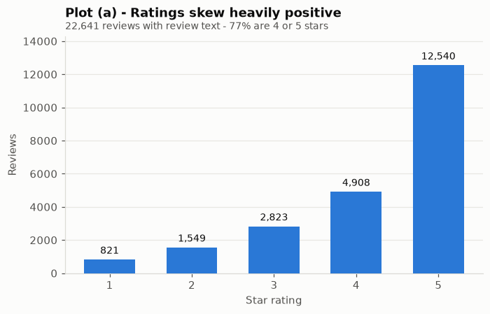

```python
# --- Plot (a): distribution of Rating ---------------------------------------
fig, ax = plt.subplots(figsize=(7, 4))
rating_counts = df["Rating"].value_counts().sort_index()

bars = ax.bar(rating_counts.index, rating_counts.values,
              color=BLUE, width=0.62, zorder=3)
# Rounded data-ends, anchored to the baseline.
for b in bars:
    b.set_linewidth(0)
# Direct labels instead of making the reader trace back to the axis.
for x, v in zip(rating_counts.index, rating_counts.values):
    ax.text(x, v + 220, f"{v:,}", ha="center", va="bottom",
            fontsize=9, color="#0b0b0b")

ax.set_xticks([1, 2, 3, 4, 5])
ax.set_ylim(0, rating_counts.max() * 1.14)
style_axes(ax, xlabel="Star rating", ylabel="Reviews",
           title="Plot (a) - Ratings skew heavily positive",
           subtitle=f"{len(df):,} reviews with review text - "
                    f"{(df['Rating'] >= 4).mean():.0%} are 4 or 5 stars")
save_fig(fig, "task1a_rating_distribution")
plt.show()
```

```
saved -> docs/figures/task1b_review_length_distribution.png
```

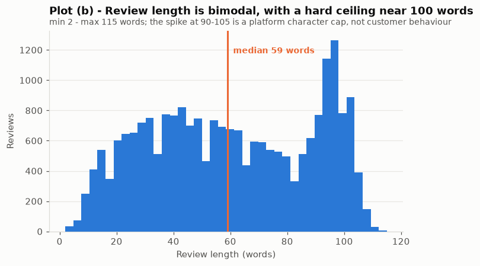

```
count    22641.0
mean        60.2
std         28.5
min          2.0
25%         36.0
50%         59.0
75%         88.0
max        115.0
```

```python
# --- Plot (b): distribution of review length in words -----------------------
# Raw word count on the untouched text; Task 2 recomputes this on cleaned text
# as the `review_length` feature.
raw_word_count = df["Review Text"].str.split().str.len()

fig, ax = plt.subplots(figsize=(7, 4))
ax.hist(raw_word_count, bins=40, color=BLUE, zorder=3)

median_len = raw_word_count.median()
ax.axvline(median_len, color=ORANGE, linewidth=2, zorder=4)
ax.text(median_len + 2, ax.get_ylim()[1] * 0.92,
        f"median {median_len:.0f} words", color=ORANGE, fontsize=9,
        ha="left", va="top", fontweight="bold")

style_axes(ax, xlabel="Review length (words)", ylabel="Reviews",
           title="Plot (b) - Review length is bimodal, with a hard ceiling near 100 words",
           subtitle=f"min {raw_word_count.min()} - max {raw_word_count.max()} words; the spike at 90-105 "
                    f"is a platform character cap, not customer behaviour")
save_fig(fig, "task1b_review_length_distribution")
plt.show()

print(raw_word_count.describe().round(1).to_string())
```

```
saved -> docs/figures/task1c_reviews_per_department.png
```

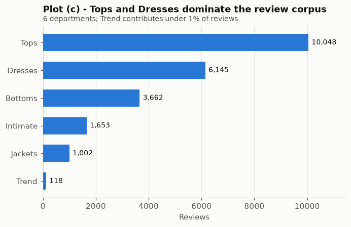

```python
# --- Plot (c): count of reviews per Department Name -------------------------
dept_counts = df["Department Name"].value_counts().sort_values()

fig, ax = plt.subplots(figsize=(7, 4))
bars = ax.barh(dept_counts.index.astype(str), dept_counts.values,
               color=BLUE, height=0.62, zorder=3)
for y, v in enumerate(dept_counts.values):
    ax.text(v + 120, y, f"{v:,}", va="center", ha="left",
            fontsize=9, color="#0b0b0b")

ax.set_xlim(0, dept_counts.max() * 1.14)
style_axes(ax, xlabel="Reviews", ylabel=None,
           title="Plot (c) - Tops and Dresses dominate the review corpus",
           subtitle=f"{df['Department Name'].nunique()} departments; "
                    f"Trend contributes under 1% of reviews",
           grid_axis="x")
save_fig(fig, "task1c_reviews_per_department")
plt.show()

RESULTS["task1"]["reviews_per_department"] = {
    str(k): int(v) for k, v in dept_counts.sort_values(ascending=False).items()
}
```

## Task 2 — NLP Feature Engineering

Order matters here: `exclam_count` and `question_count` are counted on the **original** text, *before* punctuation is stripped — strip first and the signal is gone.

**Column names created in this section** (kept exactly as specified so they are easy to locate later): `cleaned_review`, `review_length`, `exclam_count`, `question_count`, `sentiment_polarity`, `sentiment_subjectivity`.

> **Note on a spec ambiguity.** Task 2 names *five* derived numeric columns, while Tasks 3 and 6 refer to "the 4 numeric columns". We include all five columns that Task 2 names explicitly, and flag the discrepancy rather than silently dropping one.

> **Note on where sentiment is computed.** `sentiment_polarity` / `sentiment_subjectivity` are computed on the **original** review text, not the lowercased/de-punctuated version. TextBlob's pattern analyser uses punctuation and casing (notably `!` as an intensifier), so cleaning first would throw away signal the analyser is designed to use.

```python
# --- 2.1 Counts that must be taken BEFORE punctuation is removed ------------
df["exclam_count"] = df["Review Text"].str.count(r"!")
df["question_count"] = df["Review Text"].str.count(r"\?")

print("Punctuation-signal features (computed on the ORIGINAL text):")
print(df[["exclam_count", "question_count"]].describe().round(3).to_string())
print(f"\nReviews containing at least one '!': {(df['exclam_count'] > 0).mean():.1%}")
print(f"Reviews containing at least one '?': {(df['question_count'] > 0).mean():.1%}")
```

```
Punctuation-signal features (computed on the ORIGINAL text):
       exclam_count  question_count
count     22641.000       22641.000
mean          0.638           0.034
std           1.138           0.254
min           0.000           0.000
25%           0.000           0.000
50%           0.000           0.000
75%           1.000           0.000
max          41.000           6.000

Reviews containing at least one '!': 37.6%
Reviews containing at least one '?': 2.4%
```

```python
# --- 2.2 Text cleaning: lowercase, then strip punctuation -------------------
PUNCT_TABLE = str.maketrans("", "", string.punctuation)


def clean_text(text: str) -> str:
    """Lowercase, remove punctuation, and collapse whitespace."""
    text = str(text).lower().translate(PUNCT_TABLE)
    return re.sub(r"\s+", " ", text).strip()


df["cleaned_review"] = df["Review Text"].apply(clean_text)

print("Before / after cleaning:\n")
for original in df["Review Text"].head(2):
    print(f"  raw    : {original[:110]}")
    print(f"  cleaned: {clean_text(original)[:110]}\n")
```

```
Before / after cleaning:

  raw    : Absolutely wonderful - silky and sexy and comfortable
  cleaned: absolutely wonderful silky and sexy and comfortable

  raw    : Love this dress!  it's sooo pretty.  i happened to find it in a store, and i'm glad i did bc i never would hav
  cleaned: love this dress its sooo pretty i happened to find it in a store and im glad i did bc i never would have order
```

```python
# --- 2.3 review_length: word count of the CLEANED review text ---------------
df["review_length"] = df["cleaned_review"].str.split().str.len()

print(df["review_length"].describe().round(2).to_string())
```

```
count    22641.00
mean        59.96
std         28.43
min          2.00
25%         36.00
50%         59.00
75%         88.00
max        115.00
```

```python
# --- 2.4 TextBlob sentiment on the original text ----------------------------
# ~22.6k reviews; this is the slowest cell in the notebook (roughly 20-40 seconds).
sentiment = df["Review Text"].apply(lambda t: TextBlob(str(t)).sentiment)
df["sentiment_polarity"] = sentiment.apply(lambda s: s.polarity)
df["sentiment_subjectivity"] = sentiment.apply(lambda s: s.subjectivity)

NLP_NUMERIC = [
    "review_length", "exclam_count", "question_count",
    "sentiment_polarity", "sentiment_subjectivity",
]

print("Derived NLP numeric features:\n")
display(df[NLP_NUMERIC].describe().round(3))

print("\nMean polarity by Recommended IND:")
print(df.groupby("Recommended IND")["sentiment_polarity"].mean().round(4).to_string())
print("\nMean polarity by Rating:")
print(df.groupby("Rating")["sentiment_polarity"].mean().round(4).to_string())

RESULTS["task2"] = {
    "polarity_mean_by_recommend": {
        str(k): round(float(v), 4)
        for k, v in df.groupby("Recommended IND")["sentiment_polarity"].mean().items()
    },
    "polarity_mean_by_rating": {
        str(k): round(float(v), 4)
        for k, v in df.groupby("Rating")["sentiment_polarity"].mean().items()
    },
}
```

```
Derived NLP numeric features:
```

|  | review_length | exclam_count | question_count | sentiment_polarity | sentiment_subjectivity |
| --- | --- | --- | --- | --- | --- |
| count | 22641.000 | 22641.000 | 22641.000 | 22641.000 | 22641.000 |
| mean | 59.957 | 0.638 | 0.034 | 0.250 | 0.560 |
| std | 28.427 | 1.138 | 0.254 | 0.177 | 0.126 |
| min | 2.000 | 0.000 | 0.000 | -0.975 | 0.000 |
| 25% | 36.000 | 0.000 | 0.000 | 0.140 | 0.480 |
| 50% | 59.000 | 0.000 | 0.000 | 0.239 | 0.554 |
| 75% | 88.000 | 1.000 | 0.000 | 0.350 | 0.634 |
| max | 115.000 | 41.000 | 6.000 | 1.000 | 1.000 |

```
Mean polarity by Recommended IND:
Recommended IND
0    0.1293
1    0.2765

Mean polarity by Rating:
Rating
1    0.0799
2    0.1231
3    0.1672
4    0.2273
5    0.3040
```

### Write-up evidence — where sentiment and rating disagree

The required write-up asks for one concrete review where `sentiment_polarity` and `Rating` clearly point in opposite directions. We pull the most extreme case in each direction so the example is reproducible rather than cherry-picked by eye.

```python
# Case A: 5-star rating, most NEGATIVE polarity.
# Case B: 1-star rating, most POSITIVE polarity.
five_star = df[df["Rating"] == 5]
one_star = df[df["Rating"] == 1]

case_a = five_star.loc[five_star["sentiment_polarity"].idxmin()]
case_b = one_star.loc[one_star["sentiment_polarity"].idxmax()]


def show_case(label, row):
    print("=" * 78)
    print(label)
    print("=" * 78)
    print(f"Rating                 : {row['Rating']}")
    print(f"Recommended IND        : {row['Recommended IND']}")
    print(f"review_length (words)  : {row['review_length']}")
    print(f"sentiment_polarity     : {row['sentiment_polarity']:.4f}")
    print(f"sentiment_subjectivity : {row['sentiment_subjectivity']:.4f}")
    print(f"Class Name             : {row['Class Name']}")
    print(f"\nReview text:\n{row['Review Text']}\n")


show_case("CASE A - 5 stars, most negative polarity", case_a)
show_case("CASE B - 1 star, most positive polarity", case_b)

RESULTS["task2"]["disagreement_case_a"] = {
    "rating": int(case_a["Rating"]),
    "recommended_ind": int(case_a["Recommended IND"]),
    "review_length": int(case_a["review_length"]),
    "sentiment_polarity": round(float(case_a["sentiment_polarity"]), 4),
    "sentiment_subjectivity": round(float(case_a["sentiment_subjectivity"]), 4),
    "class_name": str(case_a["Class Name"]),
    "text": str(case_a["Review Text"]),
}
RESULTS["task2"]["disagreement_case_b"] = {
    "rating": int(case_b["Rating"]),
    "recommended_ind": int(case_b["Recommended IND"]),
    "review_length": int(case_b["review_length"]),
    "sentiment_polarity": round(float(case_b["sentiment_polarity"]), 4),
    "sentiment_subjectivity": round(float(case_b["sentiment_subjectivity"]), 4),
    "class_name": str(case_b["Class Name"]),
    "text": str(case_b["Review Text"]),
}

# How common is this disagreement overall? (context for the write-up)
disagree_mask = ((df["Rating"] >= 4) & (df["sentiment_polarity"] < 0)) | \
                ((df["Rating"] <= 2) & (df["sentiment_polarity"] > 0.3))
print(f"Reviews where rating and polarity clearly disagree: "
      f"{disagree_mask.sum():,} ({disagree_mask.mean():.2%} of the corpus)")
RESULTS["task2"]["polarity_rating_disagreement_count"] = int(disagree_mask.sum())
RESULTS["task2"]["polarity_rating_disagreement_pct"] = round(float(disagree_mask.mean() * 100), 2)
```

```
==============================================================================
CASE A - 5 stars, most negative polarity
==============================================================================
Rating                 : 5
Recommended IND        : 1
review_length (words)  : 51
sentiment_polarity     : -0.7000
sentiment_subjectivity : 0.6667
Class Name             : Sweaters

Review text:
I would have bought this had it not been for the way the pockets are sewn in. they are attached on the inside by a string. if the string broke the pockets would dangle. for the price you would think they would have sewn pockets in to the vest. too bad.

==============================================================================
CASE B - 1 star, most positive polarity
==============================================================================
Rating                 : 1
Recommended IND        : 0
review_length (words)  : 22
sentiment_polarity     : 0.8000
sentiment_subjectivity : 0.7500
Class Name             : Lounge

Review text:
This is a great dress if you don't want to leave the house or you want the world to see your nipples.

Reviews where rating and polarity clearly disagree: 718 (3.17% of the corpus)
```

### TF-IDF configuration

The vectoriser is **configured** here but deliberately **not fitted yet**: fitting it on the full corpus before the Task 3 split would leak validation vocabulary and validation document frequencies into training. It is fitted on the training split only in Task 3, then applied to the validation split with `.transform()`.

```python
tfidf = TfidfVectorizer(
    max_features=300,
    min_df=5,
    max_df=0.8,
    ngram_range=(1, 2),
    stop_words="english",
)
print(tfidf)
print("\nConfigured but NOT fitted - fitting happens on the training split in Task 3.")
```

```
TfidfVectorizer(max_df=0.8, max_features=300, min_df=5, ngram_range=(1, 2),
                stop_words='english')

Configured but NOT fitted - fitting happens on the training split in Task 3.
```